# donald-rumsfeld-and-big-data-beh-sci

2016-09-01 17:59:51

## About

- Associate Professor of Psychology
- Founding Director of Human Imaging at [SLEIC](http://imaging.psu.edu)
- Co-founder and Co-Director of the [Databrary.org](http://databrary.org) digital library
- A.B., Cognitive Science, Brown; M.S. & Ph.D., Cognitive Neuroscience, Carnegie Mellon University.
- Folk music, theatre, cycling, hiking, paddling, amateur radio (K3ROG)

## Overview

- Why behavioral science is harder than physics
- Why behavioral science must embrace big(ger) data
- Challenges with big data behavioral science
- Some solutions
- Let's boldly go

## Why psychology is harder than physics

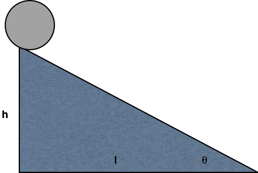

## Why psychology is harder than physics

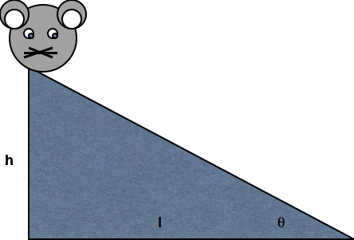

## Behavioral science must embrace big(ger) data

[figure not shown]

## Space x time x person

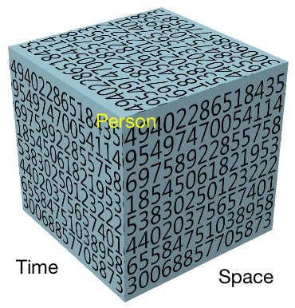

## People

- Have families
- Live in neighborhoods, cities/towns, regions, countries
- Go to schools, jobs, houses of worship
- Are richer or poorer than their neighbors

[figure not shown]

[figure not shown]

[figure not shown]

[video not shown]

[figure not shown]

[(Jean et al. 2016)](http://doi.org/10.1126/science.aaf7894)

## Poverty shrinks brains

[figure not shown]

[(Reardon 2015)](http://doi.org/10.1038/nature.2015.17227), [(Noble et al. 2015)](http://doi.org/10.1038/nn.3983)

## Overview

- Why behavioral science is harder than physics
- Why behavioral science must embrace big(ger) data
- Challenges with big data behavioral science
- Some solutions
- Let's boldly go

## Challenges with big data behavioral science

- Must gggregate, link data across **space**, **time**, **individual identities**
- Data not spatially uniform
- Time series not uniformly sampled, different sampling intervals

[figure not shown]

## Challenges with big data behavioral science

- Aggregating big data about individuals poses privacy risks

[figure not shown]

## Insight and opportunity?

- (Many) people will volunteer personal data if given something of value in return
- What value can *researchers* offer?

[figure not shown]

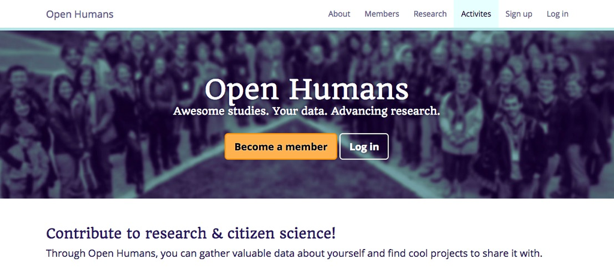

## Challenges with big data behavioral science

- Behavior rich, complex
- Many important behaviors go unmeasured
  - What did you have for breakfast this morning?
  - Last Thursday?

## Challenges with big data behavioral science

- Word and numeric measures don't fully capture phenomena

[interactive chart not shown]

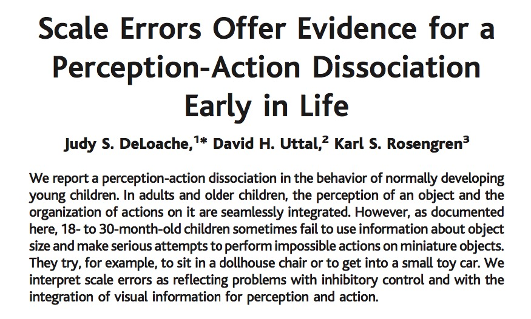

[(J. S. DeLoache, Uttal, and Rosengren 2004)](http://doi.org/10.1126/science.1093567)

[video not shown]

[(J. DeLoache 2014)](http://doi.org/10.17910/B7H019)

[video not shown]

[(Yu 2016)](http://doi.org/10.17910/B7.236)

[interactive chart not shown]

[(Batra et al. 2016)](http://doi.org/10.1542/peds.2016-1533)

[video not shown]

[(Wilkinson 2014)](http://doi.org/10.17910/B7G59R)

[video not shown]

[(Wilkinson 2014)](http://doi.org/10.17910/B7G59R)

[video not shown]

[(Wilkinson 2014)](http://doi.org/10.17910/B7G59R)

[interactive chart not shown]

## [Databrary.org](http://databrary.org)

- Digital data library specialized for research video
- Video/audio + participant/context metadata
- Share displays, materials, text-based data files
- Policy framework for sharing identifiable data
- Developmental focus, but not exclusive

## [Databrary.org](http://databrary.org) facilitates data sharing, re-use, preservation

- High capacity, centralized storage
- Transcoding to common, interoperable formats
- Long-term preservation

## Databrary helps to overcomes barriers to sharing video

- Policies for sharing identifiable video data
- Tools for reproducibly coding video
- Tools for "active curation" == during data collection
- Tools for searching, filtering

## Policies

- Restrict access to authorized researchers (& affiliates)
  - PIs and the trainees they supervise
  - Institutional [access agreement](https://databrary.org/access/policies/agreement.html)
- Seek permission to share data from participants
  - Release [template](https://databrary.org/access/policies/release-template.html); [script](https://databrary.org/access/guide/investigators/release/asking/script.html); sample [video](https://databrary.org/video/example-video-1.mp4)

## Standardized (reproducible) release levels

[figure not shown]

## Tools for coding video

- Raw research video must be coded by human observers
- [Datavyu](http://datavyu.org) a free, [open source](https://github.com/databrary/datavyu) coding tool
- Add codes, annotations time-locked to video segments
- Turn behavior into quantifiable data
- Ruby API for [scripting](https://github.com/databrary/Datavyu-Example-Scripts) reproducible workflows

[figure not shown]

[video not shown]

## What can we learn from large-scale video data sharing?

- Jayaraman, S., Smith, L.B., Raudies, F. & Gilmore, R.O. (2014). Natural Scene Statistics of Visual Experience Across Development and Culture. Databrary. Retrieved September 1, 2016 from http://doi.org/10.17910/B7988V.

## Toward a big data behavioral science

- Data sharing in open (to scientists) repositories
- Video and other spatially & temporally dense streams essential
  - Video captures behavior
  - Video improves methodological transparency

## Toward a big data behavioral science

- Linking data across time, space, individuals
- Framework for securing participant permission, limiting access
- Statistical techniques that yield discoveries

## What's Donald Rumsfeld have to do with this?

[figure not shown]

## The Rumsfeldian view of the world

|  | Knowledge | No knowledge |
| --- | --- | --- |
| Memory/awareness | Known-knowns | Known-unknowns |
| No memory/awareness | Unknown-knowns | Unknown-unknowns |

## Where we spend most of our time…

- Confirming known-knowns >>
- Testing known-unknowns >>
- Considering unknown-knowns

[figure not shown]

## Imagine a databservatory…

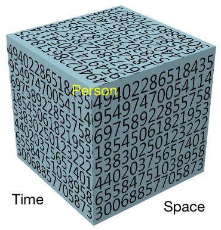

## Starting with *our* university community

[figure not shown]

## Starting with *our* university community

[figure not shown]

- App, web-framework, data-collection tool + repository + analysis platform
- [Open Humans Project](https://www.openhumans.org/) + [DataWallet](https://datawallet.io/) + [MechanicalTurk](https://www.mturk.com) + [ResearchKit](http://www.apple.com/researchkit/)/[Open Data Kit](https://opendatakit.org/)
- Link researchers with participants
- Securely store, manage, share data
- Participants get their own results + compare to others

## Acknowledgments

- [NSF BCS-1238599](http://www.nsf.gov/awardsearch/showAward?AWD_ID=1238599&HistoricalAwards=false)
- [NICHD U01-HD-076595](https://projectreporter.nih.gov/project_info_description.cfm?aid=8531595&icde=15908155&ddparam=&ddvalue=&ddsub=&cr=1&csb=default&cs=ASC)
- [Society for Research in Child Development (SRCD)](http://srcd.org)
- NYU Libraries, NYU IT, IRB, and OSP

## Stay in touch

- rogilmore@psu.edu
- github.com/gilmore-lab
- gilmore-lab.github.io

## References

Batra, Erich K., Douglas M. Teti, Eric W. Schaefer, Brooke A. Neumann, Elizabeth A. Meek, and Ian M. Paul. 2016. “Nocturnal Video Assessment of Infant Sleep Environments.” *Pediatrics*, August, e20161533. doi:10.1542/peds.2016-1533.

DeLoache, Judy. 2014. “Scale Errors Offer Evidence for a Perception-Action Dissociation Early in Life.” Databrary. doi:10.17910/B7H019.

DeLoache, Judy S., David H. Uttal, and Karl S. Rosengren. 2004. “Scale Errors Offer Evidence for a Perception-Action Dissociation Early in Life.” *Science* 304 (5673): 1027–9. doi:10.1126/science.1093567.

Jean, Neal, Marshall Burke, Michael Xie, W. Matthew Davis, David B. Lobell, and Stefano Ermon. 2016. “Combining Satellite Imagery and Machine Learning to Predict Poverty.” *Science* 353 (6301): 790–94. doi:10.1126/science.aaf7894.

Noble, Kimberly G, Suzanne M Houston, Natalie H Brito, Hauke Bartsch, Eric Kan, Joshua M Kuperman, Natacha Akshoomoff, et al. 2015. “Family Income, Parental Education and Brain Structure in Children and Adolescents.” *Nature Neuroscience* 18 (5): 773–78. doi:10.1038/nn.3983.

Reardon, Sara. 2015. “Poverty Shrinks Brains from Birth.” *Nature*, March. doi:10.1038/nature.2015.17227.

Sejnowski, Terrence J., Patricia S. Churchland, and J. Anthony Movshon. 2014. “Putting Big Data to Good Use in Neuroscience.” *Nature Neuroscience* 17 (11): 1440–1. doi:10.1038/nn.3839.

Wilkinson, Krista; 2014. “Preliminary Investigation of Visual Attention to Human Figures in Photographs: Potential Considerations for the Design of Aided AAC Visual Scene Displays.” Databrary. doi:10.17910/B7G59R.

Yu, Chen; 2016. “The Social Origins of Sustained Attention in One-Year-Old Human Infants.” Databrary. doi:10.17910/B7.236.